# Data flow, quality and standards

Jonáš Gaigr

Biodiversity Database Architecture and Data Modelling – Part 2  
Nature Conservation Agency of the Czech Republic  
Handout: db-architecture-handout.pdf

TAIEX Expert Mission on GIS and biodiversity data management | Pristina

## About me

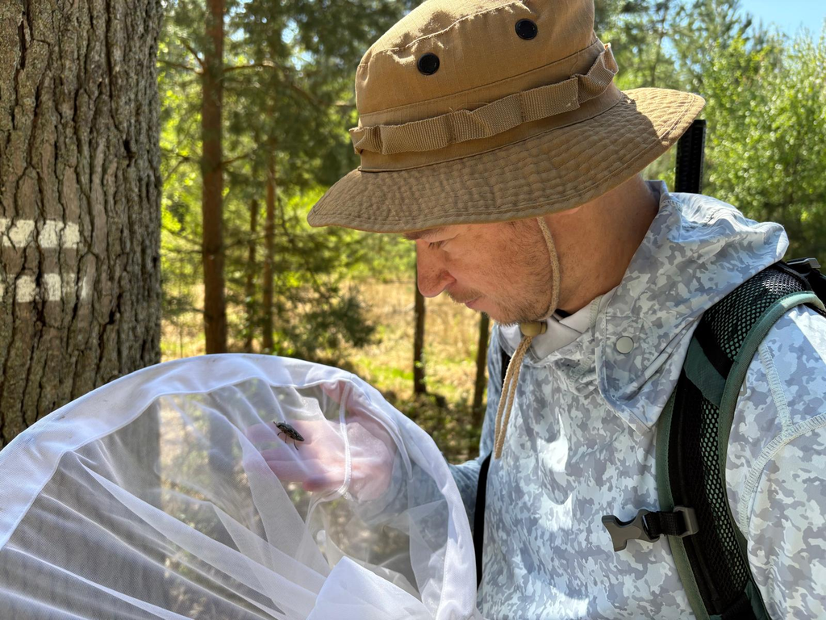

## A national database in five layers

**Reference layer** – every other layer points here

- national **checklist**, with **crosswalks** to the EU and GBIF taxonomic backbones
- **protection and Red List status**, by taxon ID
- **grids** and **protected sites**
- **habitat crosswalk** and **vocabularies**

**1 · Staging** – raw data exactly as received. Never edited.

**2 · Validation** – automatic checks and expert review. A status on every record.

**3 · Core** – verified, interpreted records. The one copy everybody uses.

**4 · Publication** – portal with sensitive species generalised · API · GBIF via the IPT · reporting

## Three sources, one path

[output not shown]

The layers are the same for every source. What differs is how much checking a record needs – and who does it.

## Flow A – structured monitoring

- **Checks built into the form:** required fields, pick-lists fed from the checklist and vocabularies, device position with its accuracy
- **Automatic sync** to staging – nobody retypes
- **The coordinator validates:** protocol followed, all visits done, values plausible
- **Stored as an event:** one visit, with its occurrences and measurements

One visit, stored as an event

Event **Visit** · pond 07 · 14 May · night torch count · 2 observers, 2 h

Occurrence *Bombina variegata* – present, 12 adults

Occurrence crested newt (*Triturus* sp.) – absent

Measurement water depth – 0.6 m

Measurement shading – 30 %

Illustrative values. The event carries the date, site, method and effort; the absence is only meaningful because of them.

## Flow B – records from trusted experts

- **Trusted status is earned:** accreditation per species group, reviewed
- **Automatic overnight import** from their app or database
- **Automatic checks:** name matches the checklist · point inside the country, plausible uncertainty · plausible date and season · far outside the known range?
- **Clean → accepted. Flagged → review queue**, not rejected

A status on every record: the NDOP example

|  | Validation – proposed by a regional expert |
| --- | --- |
| 0 | not yet validated |
| 1 | proposed as fully reliable |
| 3 | proposed as less reliable |
| 6 | proposed as erroneous |
| 9 | proposed for correction |

A central guarantor then confirms the proposal. For species protected by Czech law, species of Community interest and Annex I birds, this check is compulsory.

## Flow C – citizen science, on demand

- **Imported when needed** – for one assessment, taxon or area
- **Filters first:** open licence · community identification grade · photo
- **Expert validation** before use in any official product
- **Source always visible:** `datasetName`, `basisOfRecord`, `identificationVerificationStatus`
- **Deduplicate** – one sighting often arrives by two routes

What stays on the record after import

| Term | Value |
| --- | --- |
| datasetName | iNaturalist Research-grade Observations |
| basisOfRecord | HumanObservation |
| identificationVerificationStatus | community consensus – expert check pending |
| license | CC BY-NC 4.0 |
| associatedMedia | link to the photograph |
| occurrenceID | the platform’s own ID, kept unchanged |

Illustrative. `identificationVerificationStatus` takes free text in Darwin Core, so agree a short national list of values for it.

## Data that nobody uses do not get corrected

Build the way back in

- **Any user can flag** a record
- **The validator** for that group reviews it
- **The observer is told** – and often knows the answer
- **Every change is versioned:** who, when, why – an audit trail

The uses that find the errors

- **Art. 17 / Art. 12 reporting** – with EU accession
- **Natura 2000 / Emerald** site assessments
- **Red List** – AOO and EOO from the records (R package *ndopred*)
- **EIA and permitting**
- **Protected-area management plans**

Use → Flag → Review → Tell the observer → Correct, with a trace ↺

## Speak Darwin Core from day one

- **Use DwC directly – or keep a documented crosswalk** from every internal field
- **Occurrence** and **Event** cores; **Extended Measurement or Fact**; **Humboldt** for effort and completeness
- **Fixed values:** `basisOfRecord`; `occurrenceStatus` = present / absent
- **Mandatory:** `coordinateUncertaintyInMeters`; persistent `occurrenceID` and `eventID`
- **Pays back:** GBIF without rework · EU reporting and INSPIRE · open tools · no vendor lock-in · cross-border exchange

A crosswalk: survey spreadsheet → Darwin Core

| Your column | Darwin Core term |
| --- | --- |
| Species | scientificName + taxonID |
| Date | eventDate (2026-06-18) |
| Lat / Long | decimalLatitude / decimalLongitude |
| GPS accuracy (m) | coordinateUncertaintyInMeters |
| Found? yes / no | occurrenceStatus: present / absent |
| Record no. | occurrenceID – never reused |

The full crosswalk, with the event and measurement fields, is on the handout.

## GIS structure – one geometry, many records

Oracle Spatial (SDO) × ArcGIS geodatabase (SDE)

- **Geometry stored as `SDO_GEOMETRY`** – ArcGIS, QGIS, GDAL and plain SQL all read it. Esri’s default, `ST_Geometry`, needs Esri’s libraries for SQL
- **Tables registered with the geodatabase** – ArcGIS edits the table SQL reads; no copies to keep in sync
- **One geometry type per table** – points, lines, polygons apart; ArcGIS takes no mix
- **Same coordinate system, tolerance and spatial index** on both sides
- **Versioned edits are invisible to SQL** until posted – version only what must be

1 geometry : N records

Geometry **G-1042** · polygon · pond 07 with its shore

Occurrence *Bombina variegata* – 14 May 2026

Geometry **H-0215** · polygon · meadow segment

Habitat 6510 lowland hay meadows – 70 %

Habitat 6430 tall-herb fringes – 30 %

Illustrative. A record holds its geometry’s ID, never a shape of its own: drawn once, corrected once, and every record on it follows.

## Six habits of a database that lasts

1 **A named data steward** – and validators for each species group

Here: to be named

2 **Funded surveys deliver DwC-ready data** – written into every contract

3 **Raw data never overwritten** – provenance on every record

4 **A written sensitive-species policy** – generalise, do not hide

5 **Clear licence and citation** – so contributors get credit

6 **Start simple, then iterate** – one flow, one group, one year

## Four things to take away

1**Layers protect you** – keep the raw data, validate, then publish.

2**Every record carries a status and a source.**

3**Use is the best quality control** – build the way back in.

4**Darwin Core from day one** – every field mapped.

**For discussion – in Kosovo*:** which flow comes first? answer from the room · Who owns the national checklist? to be agreed · Who validates each species group? to be agreed

**THANK YOU FOR YOUR ATTENTION!**

github.com/jonasgaigr/kosovo-biodiversity-data-workshop-2026

[figure not shown]

aopk.gov.cz